# Project_1_Computational_Statistics

Tsadimas Argiris

2023-11-12

This report addresses a company’s need to answer the following question: What is the optimal combination of total stickers (n) and stickers per pack (k) to maximize profits?

For each combination, we calculate the expected number of packs a customer will need to complete their collection. We then determine the company’s expected income per customer, based on the expected number of packs and the varying selling price of each pack, which depends on the number of stickers it contains. Additionally, we account for the production costs of the albums and packs for each scenario to ascertain the overall profit for each combination of total stickers and stickers per pack.

Furthermore, we evaluate the probability of a customer, with a total budget of 40 euros, completing their collection for each combination of total stickers and stickers per pack.

Finally, we aim to examine the impact of allowing duplicates (two or more of the same sticker) in each pack. This analysis will consider the company’s decision-making process, the customer’s expenses, and the frequency of such occurrences

If we assume that a customer continues to buy until they complete the collection, here are our results:

```
##  Total # of stickers # of stickers per pack Expected # of Packages Profit
##                  200                      5                    235   0.70
##                  200                      6                    193   1.79
##                  200                      7                    165   2.60
##                  200                      8                    145   1.80
##                  300                      5                    372   0.44
##                  300                      6                    313   2.39
##                  300                      7                    269   3.76
##                  300                      8                    231   2.24
##                  400                      5                    520  -0.60
##                  400                      6                    433   1.99
##                  400                      7                    372   3.88
##                  400                      8                    327   2.08
```

```
## [1] "Maximum Profit: 3.88"
```

```
## [1] "This maximum profit is achieved with 400 stickers and 7 stickers per pack."
```

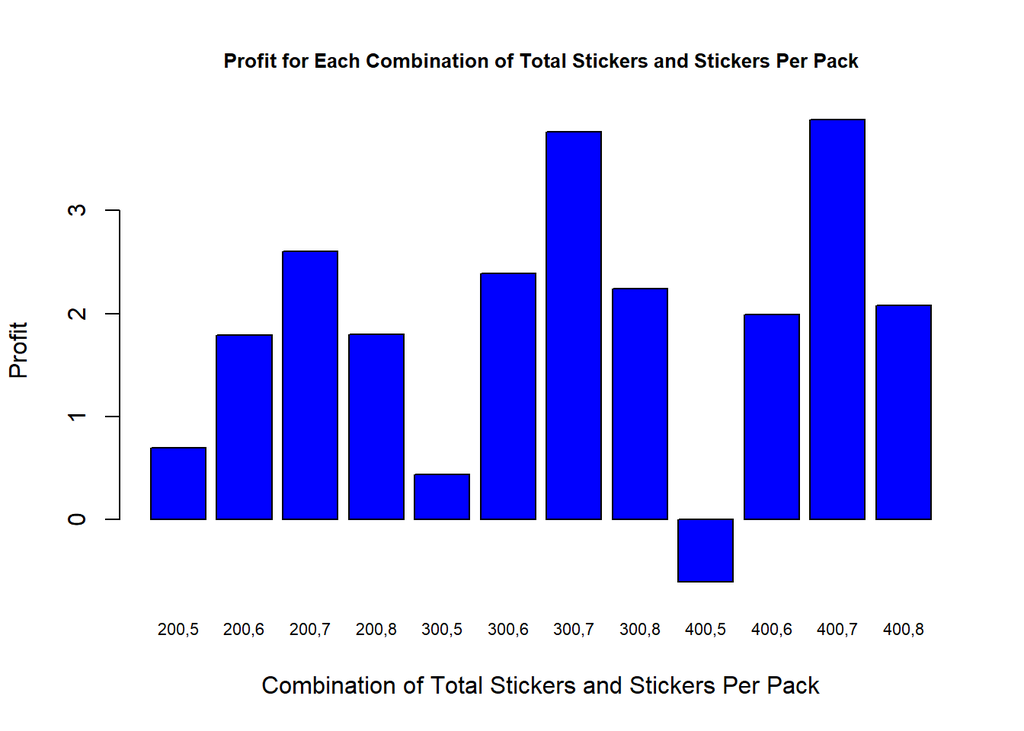

As we see in the matrix and the plot the most profitable combination for the company is achieved with 400 stickers and 7 stickers per pack. We also see in the plot that the 300,7 combination is also very profitable compared to the rest.

Now lets see the probabilities of a customer, with a total budget of 40 euros, completing their collection for each combination of total stickers and stickers per pack.

```
##  Total # of stickers # of stickers per pack Probability
##                  200                      5       0.958
##                  200                      6       0.941
##                  200                      7       0.920
##                  200                      8       0.940
##                  300                      5       0.312
##                  300                      6       0.250
##                  300                      7       0.198
##                  300                      8       0.265
##                  400                      5       0.001
##                  400                      6       0.001
##                  400                      7       0.000
##                  400                      8       0.002
```

```
## [1] "Maximum Probability: 0.958"
```

```
## [1] "This maximum probability is achieved with 200 stickers and 5 stickers per pack."
```

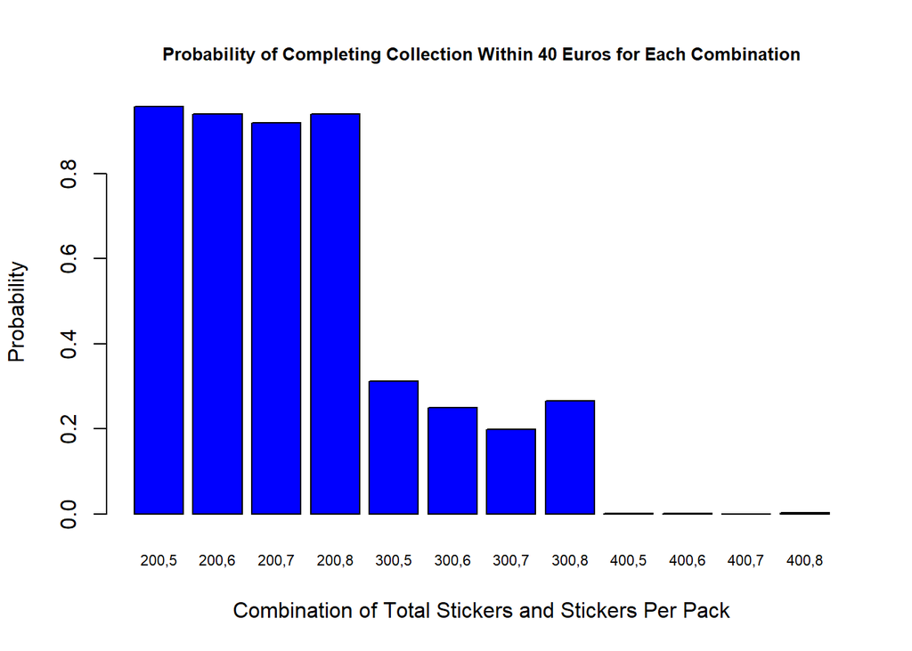

We observe that as the total number of stickers increases, the probability of a customer completing the collection decreases. Meanwhile, the number of stickers in each pack has a relatively minor effect.

This raises a crucial consideration for the company: although the 400,7 combination yields higher profits, its near-zero completion probability poses a significant concern. It prompts the question: Would it be more profitable in the long term to opt for the 300,7 combination, where a greater number of customers are likely to complete the album? If completing the album seems unattainable, there’s a risk of damaging the product’s reputation and diminishing customer interest.

Let us now examine the impact of allowing duplicates (two or more of the same sticker) in each pack.

```
##  TotalStickers StickersPerPack ExpectedPackages Profit
##            200               5              234   0.68
##            200               6              196   1.88
##            200               7              169   2.76
##            200               8              147   1.88
##            300               5              379   0.58
##            300               6              313   2.39
##            300               7              270   3.80
##            300               8              237   2.48
##            400               5              530  -0.40
##            400               6              440   2.20
##            400               7              374   3.96
##            400               8              325   2.00
```

```
## [1] "Maximum Profit: 3.96"
```

```
## [1] "This maximum profit is achieved with 400 stickers and 7 stickers per pack."
```

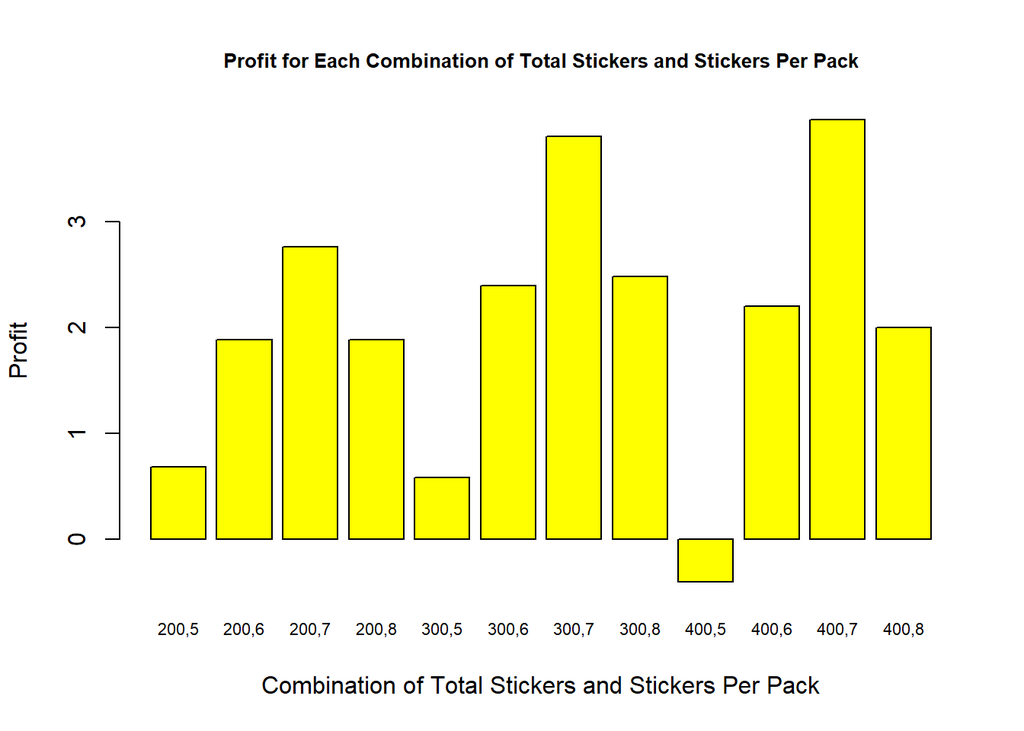

We observe that permitting duplicates (two or more identical stickers) in each pack has a negligible impact on our company’s profits.

```
##  Total # of stickers # of stickers per pack Probability
##                  200                      5       0.947
##                  200                      6       0.946
##                  200                      7       0.917
##                  200                      8       0.943
##                  300                      5       0.317
##                  300                      6       0.231
##                  300                      7       0.179
##                  300                      8       0.229
##                  400                      5       0.001
##                  400                      6       0.001
##                  400                      7       0.000
##                  400                      8       0.001
```

```
## [1] "Maximum Probability: 0.947"
```

```
## [1] "This maximum probability is achieved with 200 stickers and 5 stickers per pack."
```

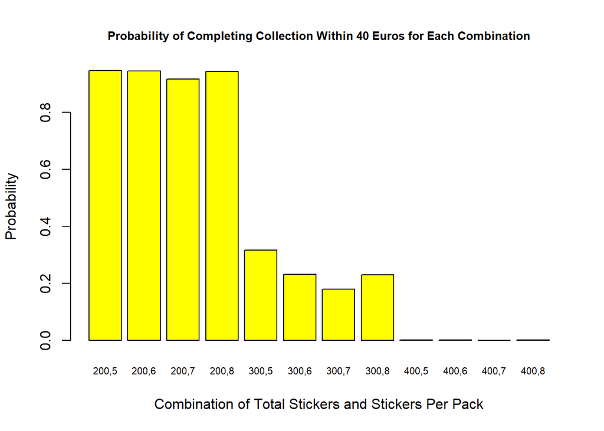

Similarly, allowing duplicates in each pack has a minimal effect on a customer’s likelihood of completing the album, indicating that it will also have a minor impact on the required budget.

```
##  Total # of stickers # of stickers per pack Probability of Duplicate
##                  200                      5               0.04841231
##                  200                      6               0.07202034
##                  200                      7               0.10151147
##                  200                      8               0.13393372
##                  300                      5               0.03308219
##                  300                      6               0.04966364
##                  300                      7               0.06772007
##                  300                      8               0.09003456
##                  400                      5               0.02474017
##                  400                      6               0.03736461
##                  400                      7               0.05176260
##                  400                      8               0.06810212
```

Here we see the probabilities for such event occuring in each case.In other words how often we will have a duplicate in 100 packs.

## Conclusion

In conclusion, our analysis reveals that while the 400 stickers with 7 stickers per pack combination offers the highest profit, its extremely low probability of collection completion poses significant risks to customer satisfaction and the product’s reputation. The 300,7 combination emerges as a viable alternative, balancing profitability with a higher likelihood of album completion. The inclusion of duplicates in packs shows negligible impact on both profit margins and completion probabilities, suggesting that this factor may not be a primary concern in decision-making. These insights should guide the company in optimizing their sticker album strategy, balancing profit with customer engagement and satisfaction. Future studies could explore customer behavior patterns and market trends to further refine these recommendations.